# Exploratory analysis: Inpatient length of stay

**PDA outcomes: 2.5. Exploratory data analysis, 2.6. Statistical analyses to identify patterns, trends and relationships in the dataset, and 2.7. Interpreting the results of statistical analysis**

This notebook explores hospital inpatient data (length of stay, total stays). We did not continue to explore these metrics for the dashboard: we chose to focus on hospital occupancy as a KPI, instead of inpatient length of stay, and I did less statistical analysis for occupancy. However, this notebook shows the exploratory analysis I did as well as some statistical analyses and interpretations for inpatient length of stay.

In particular, see the “Explore: length of stay” section (with 3 subheadings) for three examples of generated statistics (mean, totals), exploratory plots and interpretations.

Some starting Qs for exploration:

Q1: how to get to “all acute” in this data (specialties) Q2: what’s the difference in length of stay for WvS, covid?

# set up and data wrangling

```r
library(tidyverse)
library(janitor)
library(lubridate)
inpatients_specialty <- read_csv("../data/inpatient/inpatient_and_daycase_by_nhs_board_of_treatment_and_specialty.csv") %>%
  clean_names() %>%
  mutate(quarter = zoo::as.yearqtr(quarter))
head(inpatients_specialty)
```

| quarter | quarter_qf | hb | hbqf | location | location_qf | admission_type | admission_type_qf | specialty | specialty_name | episodes | length_of_episode | average_length_of_episode | average_length_of_episode_qf | spells | length_of_spell | average_length_of_spell | average_length_of_spell_qf |
| --- | --- | --- | --- | --- | --- | --- | --- | --- | --- | --- | --- | --- | --- | --- | --- | --- | --- |
| 2017 Q4 | NA | S08000015 | NA | S08000015 | d | Elective Inpatients | NA | A1 | General Medicine | 74 | 291 | 3.932432 | NA | 117 | 620 | 5.299145 | NA |
| 2018 Q1 | NA | S08000015 | NA | S08000015 | d | Elective Inpatients | NA | A1 | General Medicine | 61 | 247 | 4.049180 | NA | 101 | 421 | 4.168317 | NA |
| 2018 Q2 | NA | S08000015 | NA | S08000015 | d | Elective Inpatients | NA | A1 | General Medicine | 71 | 379 | 5.338028 | NA | 130 | 653 | 5.023077 | NA |
| 2018 Q3 | NA | S08000015 | NA | S08000015 | d | Elective Inpatients | NA | A1 | General Medicine | 50 | 173 | 3.460000 | NA | 92 | 317 | 3.445652 | NA |
| 2018 Q4 | NA | S08000015 | NA | S08000015 | d | Elective Inpatients | NA | A1 | General Medicine | 59 | 178 | 3.016949 | NA | 104 | 354 | 3.403846 | NA |
| 2019 Q1 | NA | S08000015 | NA | S08000015 | d | Elective Inpatients | NA | A1 | General Medicine | 59 | 155 | 2.627119 | NA | 85 | 293 | 3.447059 | NA |

```r
inpatients_specialty %>%
  group_by(specialty, specialty_name) %>%
  summarise(count = n())
```

| specialty | specialty_name | count |
| --- | --- | --- |
| A1 | General Medicine | 6753 |
| A2 | Cardiology | 5415 |
| A3 | Clinical Genetics | 39 |
| A6 | Infectious Diseases | 2111 |
| A7 | Dermatology | 1458 |
| A8 | Endocrinology & Diabetes | 3060 |
| A9 | Gastroenterology | 4586 |
| AB | Geriatric Medicine | 4990 |
| AD | Medical Oncology | 2596 |
| AG | Renal Medicine | 3395 |

[output cut: 21 more lines]

Which are acute?

From the [glossary](https://publichealthscotland.scot/publications/acute-hospital-activity-and-nhs-beds-information-quarterly/acute-hospital-activity-and-nhs-beds-information-quarterly-quarter-ending-30-june-2021/glossary/):

```
"'Acute' hospital care includes activity occurring in major teaching hospitals, district general hospitals and community hospitals.

Includes services such as consultation with specialist clinicians; emergency treatment; routine, complex and life-saving surgery; specialist diagnostic procedures; close observation; and short-term care of patients.

Excludes obstetric services; psychiatric services; long stay care services; and non-consultant led clinics."
```

And:

```
"A specialty is defined as a division of medicine or dentistry covering a specific area of clinical activity. There are two specialty groupings (external website) that most specialties sit in: medical and surgical. The Acute specialty grouping includes the medical and surgery groupings combined."
```

From the 31 specialties in this dataset, even though some of these specialties deal with longer term care and/or chronic conditions (such as geriatric medicine), we are not excluding any specialties, since they are included in the broad definition of ‘acute’ hospital care.

# Understanding the data we have

The data we have is inpatient and day case

- age and sex - “Age and sex breakdown for inpatient and daycase activity (episode and stays) by health board of treatment of the patients.” https://www.opendata.nhs.scot/dataset/inpatient-and-daycase-activity/resource/00c00ecc-b533-426e-a433-42d79bdea5d4
- deprivation - “Deprivation breakdown for inpatient and daycase activity (episode and stays) by health board of treatment of the patients” https://www.opendata.nhs.scot/dataset/inpatient-and-daycase-activity/resource/4fc640aa-bdd4-4fbe-805b-1da1c8ed6383
- specialty - “Specialty breakdown for inpatient and daycase activity (episode and stays) by health board of treatment of the patients.” https://www.opendata.nhs.scot/dataset/inpatient-and-daycase-activity/resource/c3b4be64-5fb4-4a2f-af41-b0012f0a276a

**What Qs can we ask?**

We can look at any of these to see overall activity over time, and look into winter/summer and COVID impacts:

- To what extent are the ‘winter crises’ reported by the media real?
- How has the Covid-19 pandemic affected provision of acute care in Scotland?

Looking at:

- Temporal: How has this issue changed over time? (Is it getting better or worse?)
- Geographic: How does this issue differ between areas in Scotland? (Where should efforts be focussed?)
- Demographic: Who is most affected by this issue? (Who should be targeted with efforts?)

To understand who is most impacted, we can look into age/sex and deprivation.

Some Qs from the brief:

- Are there any demographic groups that are driving the activity?
- Are there key cohorts of patient (based on their demographics) that drive the overall hospital activity?
- How significant is deprivation as a driver of hospital activity?
- Are there specialties that have more stable activity patterns over time and how much of an impact is stability on overall activity?
- How significant are the differences in hospital activity across the country? Does urban/rural have an impact or is it related to the size and capacity of the health board?

Look at hospital activity by season, total activity, by quarter (this is what it is grouped by)

```r
inpatients_age_sex <- read_csv("../data/inpatient/inpatient_and_daycase_by_nhs_board_of_treatment_age_and_sex.csv") %>%
  clean_names()
inpatients_deprivation <- read_csv("../data/inpatient/inpatient_and_daycase_by_nhs_board_of_treatment_and_simd.csv") %>%
  clean_names() %>%
  # change the quarter column to yearqtr type
  mutate(quarter = zoo::as.yearqtr(quarter))
```

Interesting variables:

- admission type
- sex, age (brackets) OR deprivation quintile
- episodes, length of episode, average length of episode
- stays, length of stays, average length of stays

# Explore: admission type

```r
inpatients_deprivation %>%
  distinct(admission_type)
```

| admission_type |
| --- |
| Elective Inpatients |
| Emergency Inpatients |
| Transfers |
| All Day cases |
| All Inpatients |
| All Inpatients and Day cases |
| Not Specified |

# Explore: length of stay

Specialty data contains length of episode, length of spell Deprivation data contains length of episode, length of stay Sex-age data contains length of spell, length of stay

From [glossary](https://publichealthscotland.scot/publications/acute-hospital-activity-and-nhs-beds-information-quarterly/acute-hospital-activity-and-nhs-beds-information-quarterly-quarter-ending-30-june-2021/glossary/):

```
"Episode
An SMR01 episode is generated when a patient is discharged from hospital but also when a patient is transferred between hospitals, significant facilities, specialties or to the care of a different consultant.
...
Average length of spell
This is the average (mean) number of days that a patient spends in hospital during a specialty spell at a given location. It is calculated by dividing the total length of spell for all inpatients, at a given location, during a quarter by the total number of specialty spells.

Average length of stay
This is the average (mean) number of days that a patient spends in hospital during a continuous inpatient stay (CIS). It is calculated by dividing the total length of stay for all inpatients during a quarter by the total number of CISs."
```

So length of spell is time spent in one specialty. Patient may be transferred between specialties, so length of stay is total (continuous) time in hospital (in 1 or more specialty).

Not sure how length of episode fits in here (not defined in glossary).

Let’s look at length of stay first. Length of spell or episode could be interesting if looking at individual specialties.

## length of stay ~ seasonality

Compare Q1 v Q3 for seasonality

```r
head(inpatients_deprivation)
```

| quarter | quarter_qf | hb | hbqf | location | location_qf | admission_type | admission_type_qf | simd | simdqf | episodes | length_of_episode | average_length_of_episode | average_length_of_episode_qf | stays | length_of_stay | average_length_of_stay | average_length_of_stay_qf |
| --- | --- | --- | --- | --- | --- | --- | --- | --- | --- | --- | --- | --- | --- | --- | --- | --- | --- |
| 2017 Q4 | NA | S08000015 | NA | S08000015 | d | Elective Inpatients | NA | 1 | NA | 477 | 1383 | 2.899371 | NA | 511 | 1949 | 3.814090 | NA |
| 2018 Q1 | NA | S08000015 | NA | S08000015 | d | Elective Inpatients | NA | 1 | NA | 418 | 1100 | 2.631579 | NA | 435 | 1320 | 3.034483 | NA |
| 2018 Q2 | NA | S08000015 | NA | S08000015 | d | Elective Inpatients | NA | 1 | NA | 462 | 1348 | 2.917749 | NA | 484 | 1676 | 3.462810 | NA |
| 2018 Q3 | NA | S08000015 | NA | S08000015 | d | Elective Inpatients | NA | 1 | NA | 398 | 1016 | 2.552764 | NA | 425 | 1425 | 3.352941 | NA |
| 2018 Q4 | NA | S08000015 | NA | S08000015 | d | Elective Inpatients | NA | 1 | NA | 430 | 1048 | 2.437209 | NA | 459 | 1411 | 3.074074 | NA |
| 2019 Q1 | NA | S08000015 | NA | S08000015 | d | Elective Inpatients | NA | 1 | NA | 425 | 906 | 2.131765 | NA | 446 | 1365 | 3.060538 | NA |

```r
## PDA outcomes 2.5, 2.6 and 2.7
# generate stays data for all health boards to compare individual hbs to
all_hbs_stays <- inpatients_deprivation %>%
  # calculate mean_length_of_stay per quarter
  group_by(quarter) %>%
  summarise(stays = sum(stays),
            length_of_stay = sum(length_of_stay),
            mean_length_of_stay = length_of_stay / stays) %>%
  mutate(hb = "All health boards", .after = quarter)

# select same columns from original df
stays_per_hb <- inpatients_deprivation %>%
  group_by(hb, quarter) %>%
  summarise(stays = sum(stays),
            length_of_stay = sum(length_of_stay),
            mean_length_of_stay = length_of_stay / stays) %>%
  select(quarter, hb, stays, length_of_stay, mean_length_of_stay)
```

[output not shown]

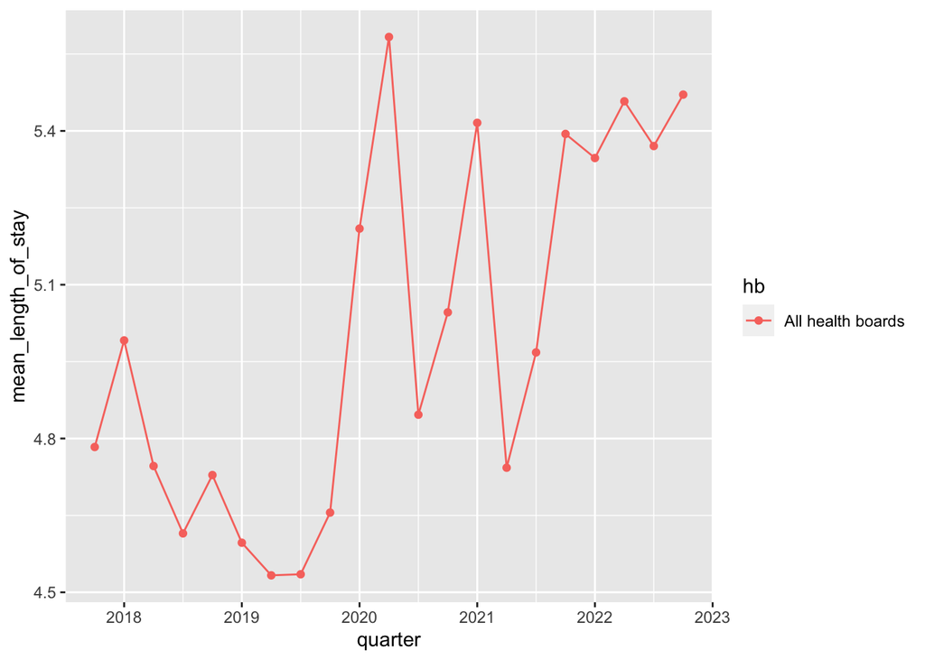

```r
# combine all_hbs data with individual hbs data
stays <- bind_rows(all_hbs_stays, stays_per_hb)

# plot mean length of stay for all health boards
stays %>%
  filter(hb == "All health boards") %>%
  ggplot() +
  aes(x = quarter, y = mean_length_of_stay, colour = hb) +
  geom_line() +
  geom_point()
```

**Interpretation:** the mean length of stay per quarter does seem to vary, but there is no clear seasonal pattern (i.e. Q1 is not alway the highest). Also there is a big increase in 2020, likely due to COVID-19 inpatients, and this peak dominates the overall trend for the data available (2017-2022).

Next, explore to try to understand what affects length of stay - look at type of admission and index of deprivation:

## length of stay ~ type of admission

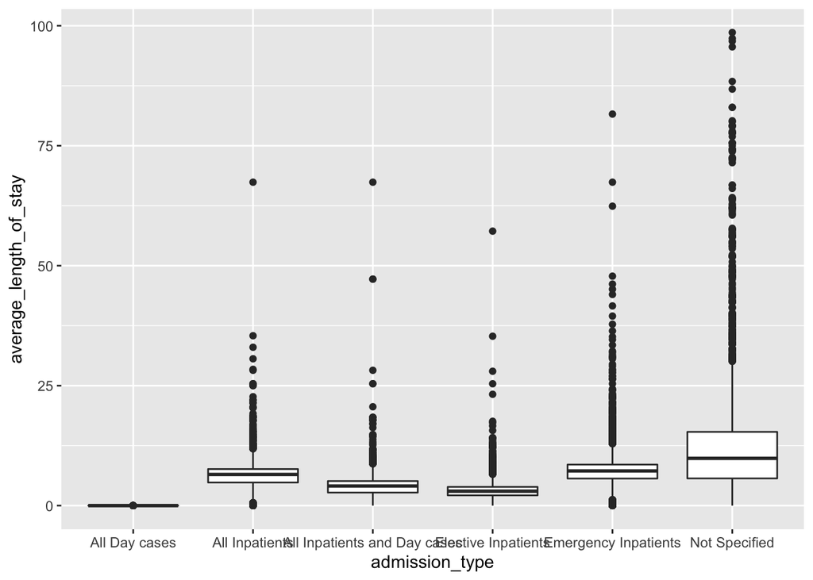

```r
## PDA outcomes 2.5, 2.6 and 2.7
# average length of stay by admission type
inpatients_deprivation %>%
  filter(average_length_of_stay < 100) %>%
  ggplot() +
  aes(x = admission_type, y = average_length_of_stay) +
  geom_boxplot()
```

**Interpretation:** The range within each is different (not specified has longer tail, and wider inter-quartile range, IQR). There may be a difference to explore between elective and emergency inpatients - these are the most different, the IQRs do not overlap. Because we did not continue to explore this for the dashboard, I did not explore this further.

## length of stay ~ index of deprivation

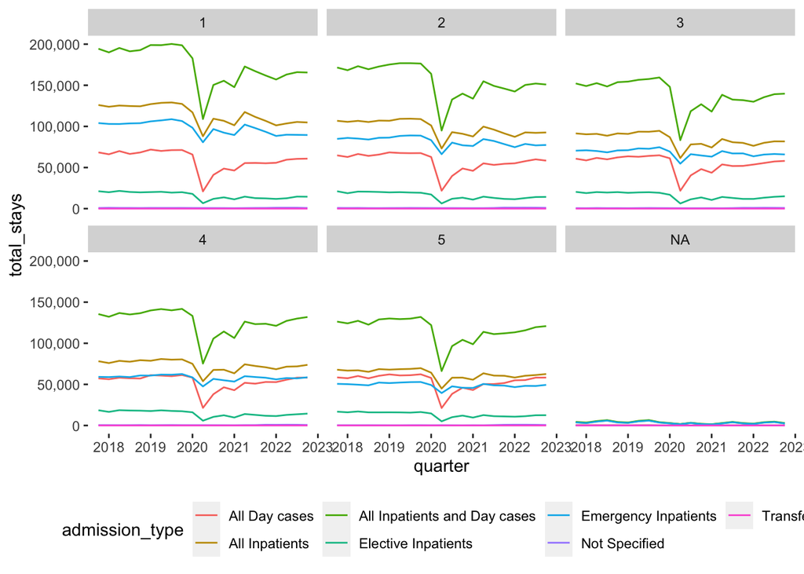

```r
## PDA outcomes 2.5, 2.6 and 2.7
# number of stays per SIMD by admission type over time
inpatients_deprivation %>%
  group_by(admission_type, quarter, simd) %>%
  summarise(total_stays = sum(stays)) %>%
  ggplot() +
  aes(x = quarter, y = total_stays, colour = admission_type) +
  geom_line() +
  facet_wrap( ~ simd, ncol = 3) +
  scale_y_continuous(labels = scales::comma_format()) +
  theme(legend.position = "bottom",
        panel.background = element_blank())
```

**Interpretation:** Across all years, people in lowest index of deprivation (1) have the most stays in hospital, and those in the least deprived have the fewest number of stays): the general trend is that the more deprived, the more stays.

# Explore: episodes by specialty

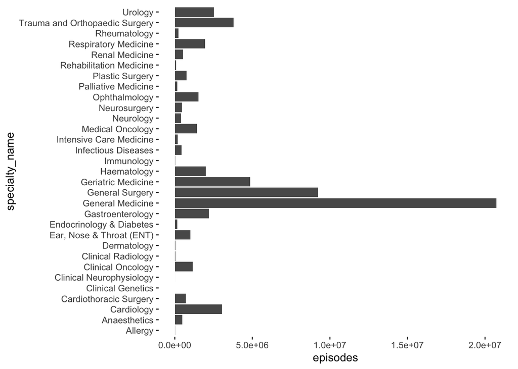

```r
inpatients_specialty %>%
  group_by(specialty_name) %>%
  summarise(episodes = sum(episodes)) %>%
  ggplot() +
  aes(y = specialty_name, x = episodes) +
  geom_col() +
  # scale_x_continuous(labels = scales::comma_format()) +
  theme(legend.position = "bottom",
        panel.background = element_blank())
```

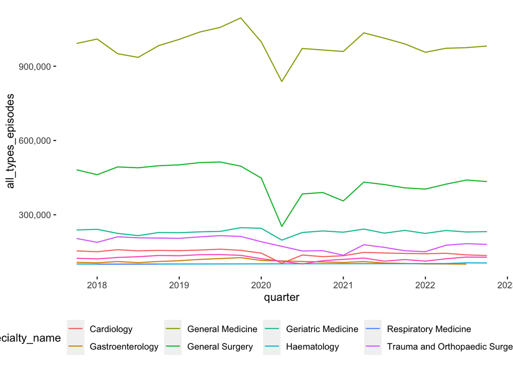

```r
inpatients_specialty %>%
  # filter(specialty_name == "General Medicine") %>%
  group_by(specialty_name, quarter) %>%
  summarise(all_types_episodes = sum(episodes)) %>%
  filter(all_types_episodes > 100000) %>%
  ggplot() +
  aes(x = quarter, y = all_types_episodes, colour = specialty_name) +
  geom_line() +
  scale_y_continuous(labels = scales::comma_format()) +
  theme(legend.position = "bottom",
        panel.background = element_blank())
```

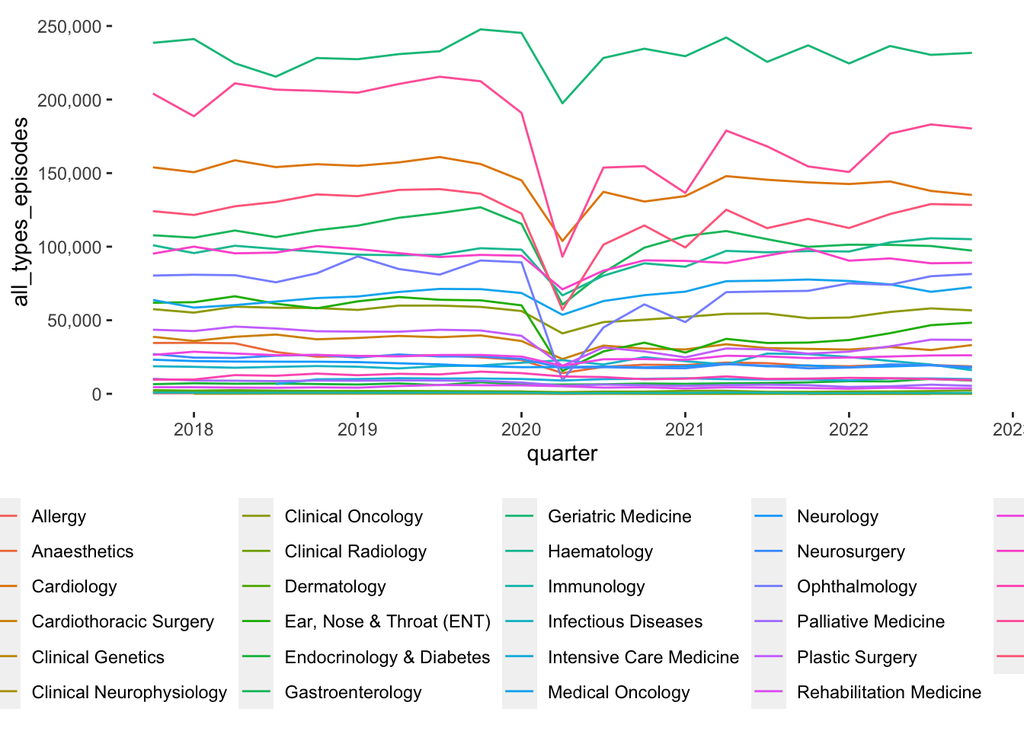

```r
inpatients_specialty %>%
  filter(!specialty_name %in% c("General Medicine","General Surgery")) %>%
  group_by(specialty_name, quarter) %>%
  summarise(all_types_episodes = sum(episodes)) %>%
  #filter(all_types_episodes > 100000) %>%
  ggplot() +
  aes(x = quarter, y = all_types_episodes, colour = specialty_name) +
  geom_line() +
  scale_y_continuous(labels = scales::comma_format()) +
  theme(legend.position = "bottom",
        panel.background = element_blank()) #+
```

```r
  #facet_wrap(~ specialty_name, ncol = 2, scales = "free_y")
```

# Further Qs

Who is impacted by W/S / covid patterns?

Are there key patient groups driving/most affected by any seasonal pattern?

(Where do these cases come from? Look at A&E discharges “admitted to same hospital” from A&E discharge data for same time period)